# Taxi Data New York

Using ML Techniques

Japekam Dang

# 1. Introduction

In this lab, the objective was to construct a predictive model to estimate the tip amount given to New York City taxi drivers based on various features of the trip. The model was developed using data from Week 2 of February 2017 and was evaluated on data from Week 4 of the same month. The main goal was to find a model that generalizes well to unseen data, with Mean Squared Prediction Error (MSPE) serving as the primary metric for evaluating model performance.

# 2. Data Loading and Initial Exploration

## 2.1 Data Loading and Initial Exploration

The datasets for Week 2 and Week 4 of February 2017 were loaded, along with a zone lookup table, to potentially map location IDs to geographic names. The initial exploration involved examining the structure and contents of the Week 2 dataset to understand the variables and identify any immediate issues, such as missing values or irrelevant columns.

```r
week2_data <- read_csv("week2.csv")
week4_data <- read_csv("week4.csv")
zone_lookup <- read_csv("taxi+_zone_lookup.csv")
head(week2_data)
```

```
## # A tibble: 6 × 19
##   VendorID tpep_pickup_datetime tpep_dropoff_datetime passenger_count
##      <dbl> <dttm>               <dttm>                          <dbl>
## 1        1 2017-02-06 00:55:55  2017-02-06 00:56:24                 1
## 2        1 2017-02-06 00:46:20  2017-02-06 00:46:25                 1
## 3        1 2017-02-06 00:24:13  2017-02-06 00:32:15                 1
## 4        1 2017-02-06 00:51:02  2017-02-06 00:56:06                 1
## 5        1 2017-02-06 00:11:34  2017-02-06 00:11:41                 2
## 6        1 2017-02-06 00:16:11  2017-02-06 00:20:42                 2
## # ℹ 15 more variables: trip_distance <dbl>, RatecodeID <dbl>,
## #   store_and_fwd_flag <chr>, PULocationID <dbl>, DOLocationID <dbl>,
## #   payment_type <dbl>, fare_amount <dbl>, extra <dbl>, mta_tax <dbl>,
## #   tip_amount <dbl>, tolls_amount <dbl>, improvement_surcharge <dbl>,
## #   total_amount <dbl>, congestion_surcharge <lgl>, airport_fee <lgl>
```

```r
head(week4_data)
```

```
## # A tibble: 6 × 19
##   VendorID tpep_pickup_datetime tpep_dropoff_datetime passenger_count
##      <dbl> <dttm>               <dttm>                          <dbl>
## 1        1 2017-02-20 00:06:43  2017-02-20 00:18:10                 1
## 2        1 2017-02-20 00:22:01  2017-02-20 00:53:02                 1
## 3        1 2017-02-20 00:02:12  2017-02-20 00:02:36                 1
## 4        1 2017-02-20 00:39:55  2017-02-20 00:49:41                 1
## 5        1 2017-02-20 00:17:20  2017-02-20 00:22:46                 1
## 6        1 2017-02-20 00:04:24  2017-02-20 00:11:42                 2
## # ℹ 15 more variables: trip_distance <dbl>, RatecodeID <dbl>,
## #   store_and_fwd_flag <chr>, PULocationID <dbl>, DOLocationID <dbl>,
## #   payment_type <dbl>, fare_amount <dbl>, extra <dbl>, mta_tax <dbl>,
## #   tip_amount <dbl>, tolls_amount <dbl>, improvement_surcharge <dbl>,
## #   total_amount <dbl>, congestion_surcharge <lgl>, airport_fee <lgl>
```

```r
summary(week2_data)
```

```
##     VendorID     tpep_pickup_datetime
##  Min.   :1.000   Min.   :2017-02-06 00:00:00.00
##  1st Qu.:1.000   1st Qu.:2017-02-07 20:06:01.00
##  Median :2.000   Median :2017-02-09 20:07:45.00
##  Mean   :1.554   Mean   :2017-02-09 16:27:44.52
##  3rd Qu.:2.000   3rd Qu.:2017-02-11 12:37:20.50
##  Max.   :2.000   Max.   :2017-02-12 23:59:59.00
##  tpep_dropoff_datetime           passenger_count trip_distance
##  Min.   :2017-01-24 15:39:43.0   Min.   :0.000   Min.   :  0.000
##  1st Qu.:2017-02-07 20:18:50.0   1st Qu.:1.000   1st Qu.:  0.950
##  Median :2017-02-09 20:18:59.0   Median :1.000   Median :  1.600
##  Mean   :2017-02-09 16:42:56.0   Mean   :1.625   Mean   :  2.754
##  3rd Qu.:2017-02-11 12:51:56.0   3rd Qu.:2.000   3rd Qu.:  2.900
##  Max.   :2017-02-13 23:11:31.0   Max.   :9.000   Max.   :282.000
##    RatecodeID    store_and_fwd_flag  PULocationID    DOLocationID
##  Min.   : 1.00   Length:2201171     Min.   :  1.0   Min.   :  1.0
##  1st Qu.: 1.00   Class :character   1st Qu.:114.0   1st Qu.:107.0
##  Median : 1.00   Mode  :character   Median :162.0   Median :162.0
##  Mean   : 1.04                      Mean   :163.4   Mean   :161.2
##  3rd Qu.: 1.00                      3rd Qu.:233.0   3rd Qu.:233.0
##  Max.   :99.00                      Max.   :265.0   Max.   :265.0
##   payment_type    fare_amount           extra           mta_tax
##  Min.   :1.000   Min.   :  -175.0   Min.   :-4.610   Min.   :-0.5000
##  1st Qu.:1.000   1st Qu.:     6.5   1st Qu.: 0.000   1st Qu.: 0.5000
##  Median :1.000   Median :     9.0   Median : 0.000   Median : 0.5000
##  Mean   :1.319   Mean   :    12.5   Mean   : 0.333   Mean   : 0.4975
##  3rd Qu.:2.000   3rd Qu.:    14.0   3rd Qu.: 0.500   3rd Qu.: 0.5000
##  Max.   :4.000   Max.   :361770.2   Max.   : 4.500   Max.   :73.0000
##    tip_amount       tolls_amount      improvement_surcharge  total_amount
##  Min.   :-10.560   Min.   :-10.0000   Min.   :-0.3000       Min.   :  -175.3
##  1st Qu.:  0.000   1st Qu.:  0.0000   1st Qu.: 0.3000       1st Qu.:     8.3
##  Median :  1.360   Median :  0.0000   Median : 0.3000       Median :    11.6
##  Mean   :  1.801   Mean   :  0.2637   Mean   : 0.2996       Mean   :    15.7
##  3rd Qu.:  2.360   3rd Qu.:  0.0000   3rd Qu.: 0.3000       3rd Qu.:    17.1
##  Max.   :462.240   Max.   :580.2100   Max.   : 0.3000       Max.   :361772.0
##  congestion_surcharge airport_fee
##  Mode:logical         Mode:logical
##  NA's:2201171         NA's:2201171
##
##
##
##
```

```r
glimpse(week2_data)
```

```
## Rows: 2,201,171
## Columns: 19
## $ VendorID              <dbl> 1, 1, 1, 1, 1, 1, 1, 1, 2, 2, 1, 1, 1, 1, 1, 2, …
## $ tpep_pickup_datetime  <dttm> 2017-02-06 00:55:55, 2017-02-06 00:46:20, 2017-…
## $ tpep_dropoff_datetime <dttm> 2017-02-06 00:56:24, 2017-02-06 00:46:25, 2017-…
## $ passenger_count       <dbl> 1, 1, 1, 1, 2, 2, 1, 2, 2, 2, 1, 1, 2, 1, 1, 5, …
## $ trip_distance         <dbl> 0.00, 0.00, 2.70, 1.10, 0.00, 1.50, 3.10, 0.70, …
## $ RatecodeID            <dbl> 1, 1, 1, 1, 1, 1, 1, 1, 1, 1, 5, 1, 1, 1, 1, 1, …
## $ store_and_fwd_flag    <chr> "N", "N", "N", "N", "N", "N", "N", "N", "N", "N"…
## $ PULocationID          <dbl> 168, 168, 142, 238, 145, 107, 141, 48, 116, 42, …
## $ DOLocationID          <dbl> 168, 168, 151, 236, 145, 162, 246, 230, 42, 42, …
## $ payment_type          <dbl> 2, 2, 2, 2, 2, 2, 1, 1, 1, 1, 2, 1, 2, 1, 1, 2, …
## $ fare_amount           <dbl> 2.5, 2.5, 9.5, 6.5, 2.5, 6.5, 13.0, 5.0, 5.5, 4.…
## $ extra                 <dbl> 0.5, 0.5, 0.5, 0.5, 0.5, 0.5, 0.5, 0.5, 0.5, 0.5…
## $ mta_tax               <dbl> 0.5, 0.5, 0.5, 0.5, 0.5, 0.5, 0.5, 0.5, 0.5, 0.5…
## $ tip_amount            <dbl> 0.00, 0.00, 0.00, 0.00, 0.00, 0.00, 1.00, 1.25, …
## $ tolls_amount          <dbl> 0.00, 0.00, 0.00, 0.00, 0.00, 0.00, 0.00, 0.00, …
## $ improvement_surcharge <dbl> 0.3, 0.3, 0.3, 0.3, 0.3, 0.3, 0.3, 0.3, 0.3, 0.3…
## $ total_amount          <dbl> 3.80, 3.80, 10.80, 7.80, 3.80, 7.80, 15.30, 7.55…
## $ congestion_surcharge  <lgl> NA, NA, NA, NA, NA, NA, NA, NA, NA, NA, NA, NA, …
## $ airport_fee           <lgl> NA, NA, NA, NA, NA, NA, NA, NA, NA, NA, NA, NA, …
```

## 2.2 Initial Data Cleaning

```r
# Drop irrelevant columns and filter out rows with missing or invalid data
week2_cleaned <- week2_data %>%
  select(-c(congestion_surcharge, airport_fee)) %>%
  filter(!is.na(tip_amount) & fare_amount > 0 & trip_distance > 0)

# Check for remaining missing values
week2_cleaned %>% summarise_all(funs(sum(is.na(.))))
```

```
## # A tibble: 1 × 17
##   VendorID tpep_pickup_datetime tpep_dropoff_datetime passenger_count
##      <int>                <int>                 <int>           <int>
## 1        0                    0                     0               0
## # ℹ 13 more variables: trip_distance <int>, RatecodeID <int>,
## #   store_and_fwd_flag <int>, PULocationID <int>, DOLocationID <int>,
## #   payment_type <int>, fare_amount <int>, extra <int>, mta_tax <int>,
## #   tip_amount <int>, tolls_amount <int>, improvement_surcharge <int>,
## #   total_amount <int>
```

## 2.3 Outlier Detection and Removal

```r
# Calculate thresholds for outliers using the 1st and 99th percentiles
tip_upper_threshold <- quantile(week2_cleaned$tip_amount, 0.99)
fare_upper_threshold <- quantile(week2_cleaned$fare_amount, 0.99)
distance_upper_threshold <- quantile(week2_cleaned$trip_distance, 0.99)

# Remove outliers based on the calculated thresholds
week2_cleaned <- week2_cleaned %>%
  filter(tip_amount <= tip_upper_threshold,
         fare_amount <= fare_upper_threshold,
         trip_distance <= distance_upper_threshold)
```

# 3. Data Transformation

## 3.1 Feature Engineering

Feature engineering was a crucial step to enhance the predictive power of the model. In this step, we performed several data transformations to prepare the `week2_cleaned` dataset for further analysis:

1. **Extracting the Pickup Hour (`pickup_hour`)**:
   - We used the `hour()` function to extract the hour from the `tpep_pickup_datetime` column. This allows us to analyze patterns in taxi pickups based on the time of day.
2. **Extracting the Day of the Week (`day_of_week`)**:
   - The `wday()` function was employed to extract the day of the week from the `tpep_pickup_datetime` column, with labels for each day (e.g., “Mon”, “Tue”). This helps in examining trends across different days of the week.
3. **Calculating Trip Duration (`trip_duration`)**:
   - We calculated the duration of each trip in minutes using the difference between the pickup and dropoff times. Trip duration is a key factor that could influence fare and tip amounts.
4. **Categorizing Trip Distance (`trip_distance_bin`)**:
   - The continuous `trip_distance` variable was categorized into bins labeled “Short”, “Medium”, “Long”, and “Very Long”. Binning simplifies the analysis by grouping trips of similar distances together.
5. **Categorizing Fare Amount (`fare_bin`)**:
   - Similarly, the `fare_amount` variable was categorized into “Low”, “Medium”, “High”, and “Very High” bins. This categorization aids in identifying trends and differences across fare ranges.
6. **Factorizing Payment Type (`payment_type`)**:
   - The `payment_type` variable was converted into a factor with labels “Credit Card”, “Cash”, “No Charge”, and “Dispute”. Understanding the distribution of payment types can provide insights into customer behavior and payment preferences.

These transformations are crucial for cleaning and structuring the data, making it more suitable for exploratory data analysis and subsequent modeling tasks.

```r
week2_cleaned <- week2_cleaned %>%
  mutate(
    pickup_hour = hour(tpep_pickup_datetime),
    dropoff_hour = hour(tpep_dropoff_datetime),
    day_of_week = wday(tpep_pickup_datetime, label = TRUE),
    trip_duration = as.numeric(difftime(tpep_dropoff_datetime, tpep_pickup_datetime, units = "mins")),
    trip_distance_bin = cut(trip_distance, breaks = c(0, 2, 5, 10, Inf), labels = c("Short", "Medium", "Long", "Very Long")),
    fare_bin = cut(fare_amount, breaks = c(0, 10, 20, 30, Inf), labels = c("Low", "Medium", "High", "Very High")),
    payment_type = factor(payment_type, levels = c(1, 2, 3, 4), labels = c("Credit Card", "Cash", "No Charge", "Dispute"))
  )
```

## 3.2 Sampling for EDA

Given the large size of the dataset, a random 10% subsample was taken to facilitate faster exploratory data analysis (EDA). This sampling approach allowed us to efficiently generate visualizations and insights without compromising the overall integrity of the analysis.

```r
# Set a seed for reproducibility
set.seed(123)

# Take a random 10% subsample of the data
sampled_data <- week2_data %>% sample_frac(0.1)
sample_cleaned <- week2_cleaned %>% sample_frac(0.1)

# Check the size of the subsample
nrow(sampled_data)
```

```
## [1] 220117
```

```r
nrow(sample_cleaned)
```

```
## [1] 214816
```

# 4. Exploratory Data Analysis (EDA)

## 4.1 Distribution of Tip Amounts

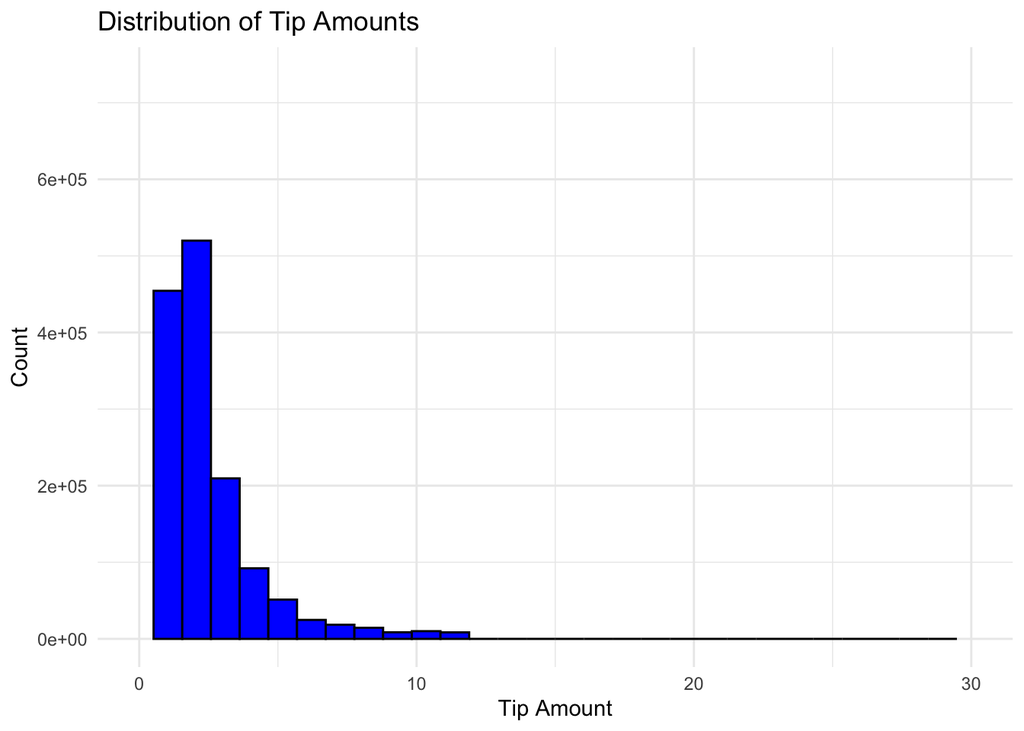

```r
# Plot the distribution of tip amounts
ggplot(week2_cleaned, aes(x = tip_amount)) +
  geom_histogram(bins = 30, fill = "blue", color = "black") +
  theme_minimal() +
  labs(title = "Distribution of Tip Amounts", x = "Tip Amount", y = "Count") +
  xlim(0,30)
```

This histogram visualizes the frequency of different tip amounts, revealing that most tips are concentrated at lower values, with a significant drop-off as the tip amount increases.

## 4.2 Distribution of Trip Distances

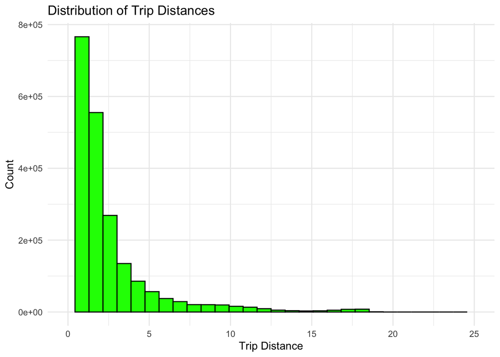

```r
# Plot the distribution of trip distances
ggplot(week2_cleaned, aes(x = trip_distance)) +
  geom_histogram(bins = 30, fill = "green", color = "black") +
  theme_minimal() +
  labs(title = "Distribution of Trip Distances", x = "Trip Distance", y = "Count") +
  xlim(0,25)
```

This histogram displays the frequency of different trip distances, showing that the majority of trips are relatively short, with a sharp decrease in the number of longer trips.

## 4.3 Density Plot of Fare Amounts

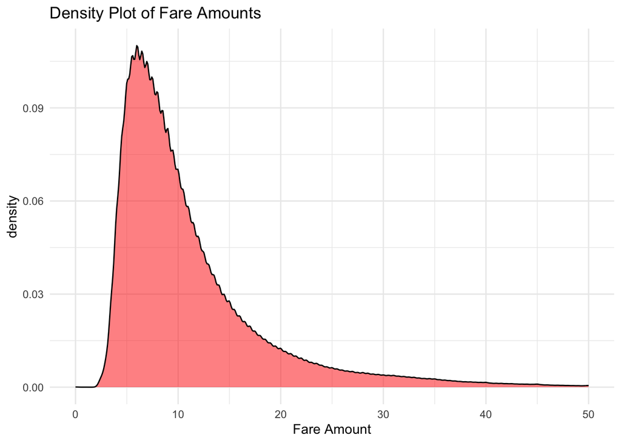

```r
# Density plot for fare amounts
ggplot(week2_cleaned, aes(x = fare_amount)) +
  geom_density(fill = "red", alpha = 0.5) +
  theme_minimal() +
  labs(title = "Density Plot of Fare Amounts", x = "Fare Amount") +
  xlim(0,50)
```

This density plot shows the distribution of fare amounts, highlighting that most fares are clustered around lower values, with a gradual decline as the fare amount increases.

## 4.4 Distribution of Payment Types

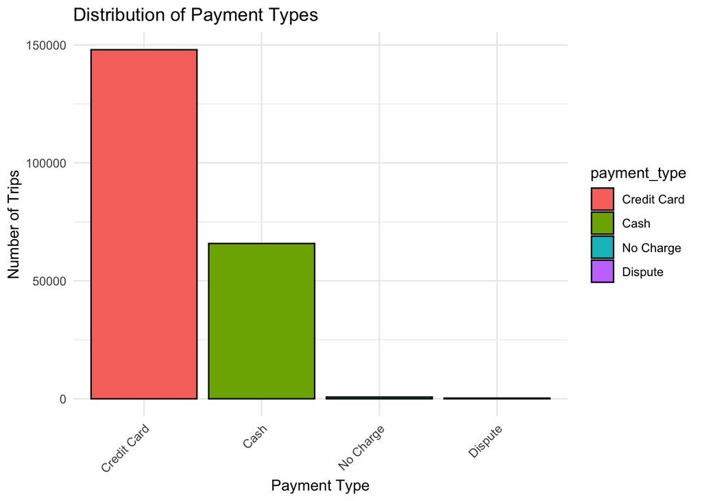

```r
# Count the number of trips for each payment type
payment_type_distribution <- sample_cleaned %>%
  group_by(payment_type) %>%
  summarise(count = n())

# Plot the distribution of payment types with custom labels
ggplot(payment_type_distribution, aes(x = payment_type, y = count, fill = payment_type)) +
  geom_bar(stat = "identity", color = "black") +
  theme_minimal() +
  labs(title = "Distribution of Payment Types",
       x = "Payment Type", y = "Number of Trips") +
  theme(axis.text.x = element_text(angle = 45, hjust = 1))
```

This bar chart visualizes the distribution of different payment types used by passengers. The majority of trips are paid using credit cards, indicating a preference for electronic payments. Cash is the second most common payment method, while “No Charge” and “Dispute” categories are relatively rare, suggesting that issues with payment or non-payment are uncommon.

## 4.5 Scatter Plot of Fare Amount vs. Tip Amount

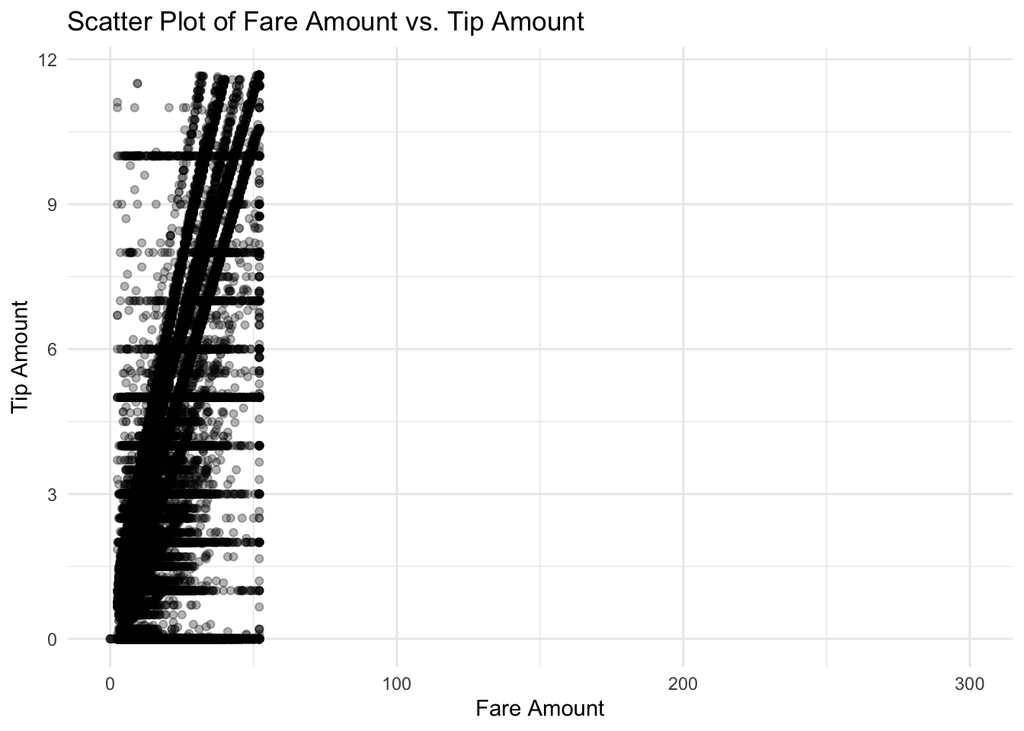

```r
# Scatter plot of fare amount vs. tip amount
ggplot(sample_cleaned, aes(x = fare_amount, y = tip_amount)) +
  geom_point(alpha = 0.3) +
  theme_minimal() +
  labs(title = "Scatter Plot of Fare Amount vs. Tip Amount", x = "Fare Amount", y = "Tip Amount") +
  xlim(0,300)
```

## 4.6 Scatter Plot of Trip Distance vs. Tip Amount

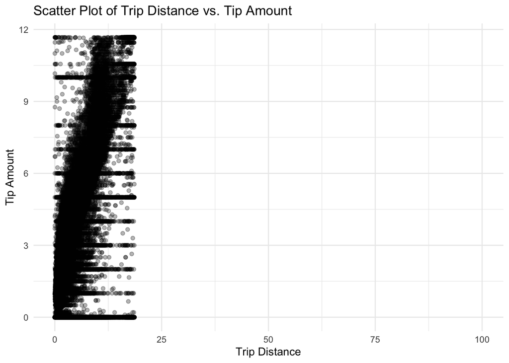

```r
# Scatter plot of trip distance vs. tip amount
ggplot(sample_cleaned, aes(x = trip_distance, y = tip_amount)) +
  geom_point(alpha = 0.3) +
  theme_minimal() +
  labs(title = "Scatter Plot of Trip Distance vs. Tip Amount", x = "Trip Distance", y = "Tip Amount") +
  xlim(0,100)
```

This scatter plot examines the relationship between trip distance and tip amount. While there is some indication that longer trips might result in higher tips, the plot shows significant variability. Many shorter trips also yield higher tips, suggesting that factors other than trip distance play a role in determining tip amounts.

## 4.7 Scatter Plot of Fare Amount vs. Tip Amount by Trip Distance

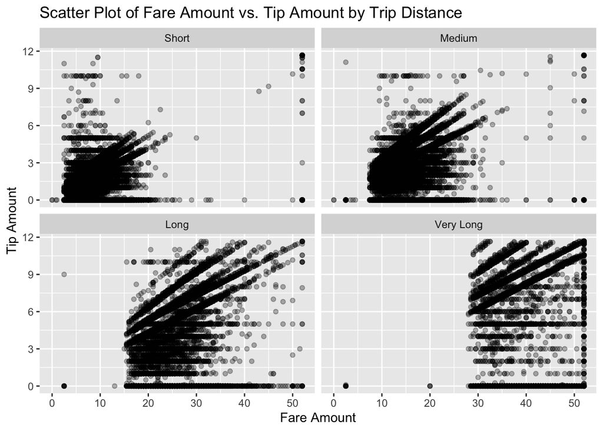

```r
ggplot(sample_cleaned, aes(x = fare_amount, y = tip_amount)) +
  geom_point(alpha = 0.3) +
  facet_wrap(~ trip_distance_bin) +
  labs(title = "Scatter Plot of Fare Amount vs. Tip Amount by Trip Distance", x = "Fare Amount", y = "Tip Amount")
```

In this analysis, I created a faceted scatter plot to examine the relationship between fare amount and tip amount across different trip distance categories (“Short”, “Medium”, “Long”, “Very Long”). By faceting the plot by `trip_distance_bin`, we can observe how the relationship between fare and tip varies depending on the length of the trip.

The faceted plots made it easier to compare these relationships side by side.

## 4.8 Passenger Count vs. Tip Amount (Violin Plot)

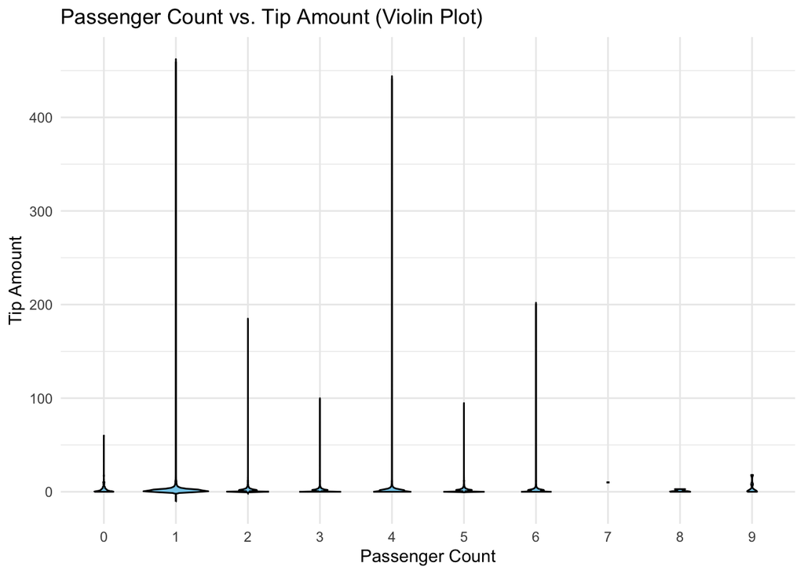

```r
# Convert passenger_count to a factor
week2_data <- week2_data %>%
  mutate(passenger_count = factor(passenger_count))

# Violin plot for Passenger Count vs. Tip Amount
ggplot(week2_data, aes(x = passenger_count, y = tip_amount)) +
  geom_violin(fill = "skyblue", color = "black") +
  theme_minimal() +
  labs(title = "Passenger Count vs. Tip Amount (Violin Plot)", x = "Passenger Count", y = "Tip Amount")
```

This violin plot visualizes the distribution of tip amounts across different passenger counts, allowing us to see how tips vary with the number of passengers. The plot highlights the spread and density of tips for each passenger count category.

## 4.9(a) Pickup Hour vs. Tip Amount (Initial Attempt)

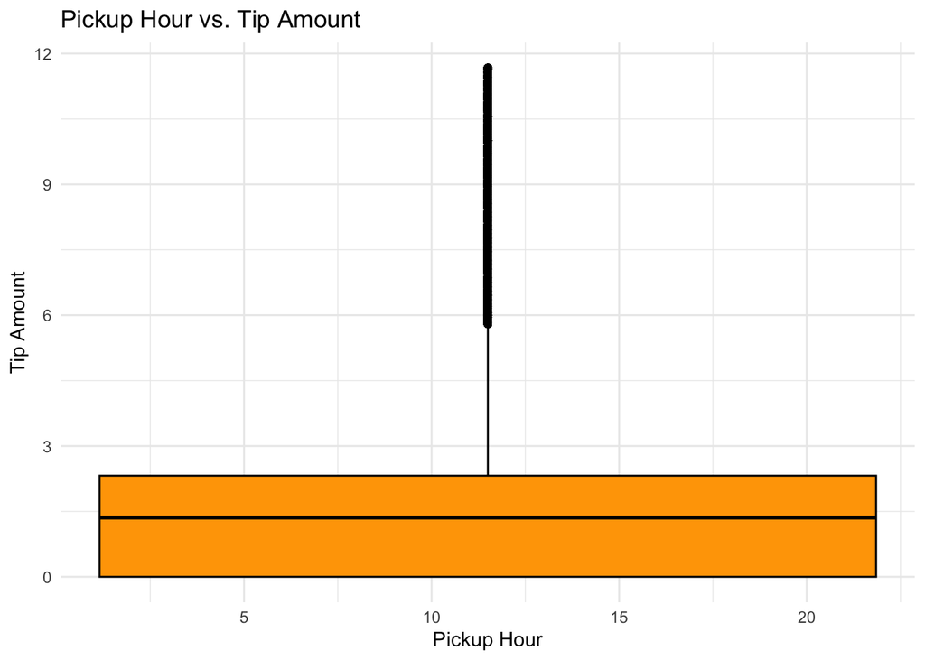

```r
# Plot relationship between Pickup Hour and Tip Amount
ggplot(sample_cleaned, aes(x = pickup_hour, y = tip_amount)) +
  geom_boxplot(fill = "orange", color = "black") +
  theme_minimal() +
  labs(title = "Pickup Hour vs. Tip Amount", x = "Pickup Hour", y = "Tip Amount")
```

In the initial attempt to create a box plot showing the relationship between pickup hour and tip amount, I encountered an issue where the plot didn’t display the data correctly. The box plot appeared condensed, with the x-axis not appropriately reflecting the hourly data. This happened because the `pickup_hour` variable was treated as a continuous numeric variable rather than a categorical one.

## 4.9(b) Pickup Hour vs. Tip Amount (Corrected Approach)

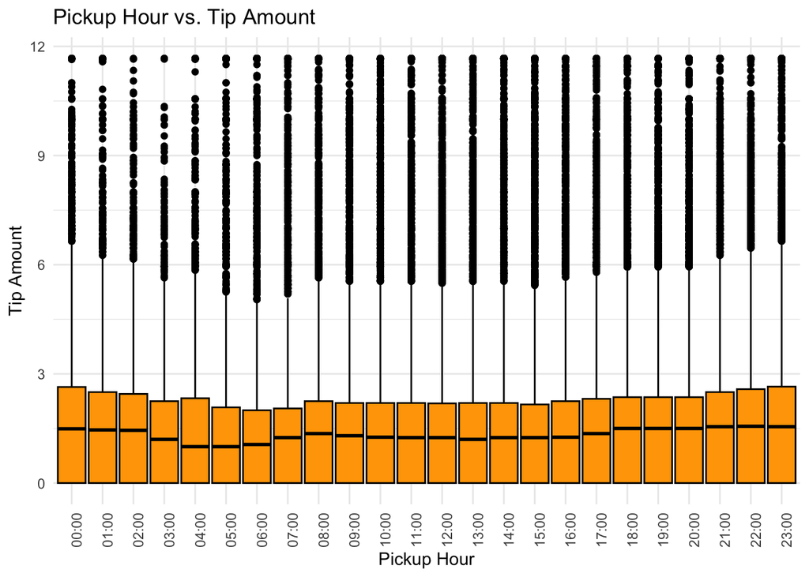

```r
# Include the updated code for creating the boxplot
sample_cleaned <- sample_cleaned %>%
  mutate(pickup_hour = factor(pickup_hour, levels = 0:23, labels = sprintf("%02d:00", 0:23)))

ggplot(sample_cleaned, aes(x = pickup_hour, y = tip_amount)) +
  geom_boxplot(fill = "orange", color = "black", width = 0.9) +
  theme_minimal() +
  labs(title = "Pickup Hour vs. Tip Amount", x = "Pickup Hour", y = "Tip Amount") +
  theme(axis.text.x = element_text(angle = 90, hjust = 1))
```

To address the issue, I converted the `pickup_hour` variable into a factor with levels representing each hour of the day. This allowed the box plot to correctly represent each hour on the x-axis, displaying the distribution of tip amounts across different hours more effectively. The x-axis labels were also rotated for better readability.

## 4.10(a) Is Night vs. Tip Amount (Initial Attempt)

```r
# Create a flag for night trips
sample_cleaned <- sample_cleaned %>%
  mutate(is_night = ifelse(pickup_hour >= 22 | pickup_hour <= 5, 1, 0))
```

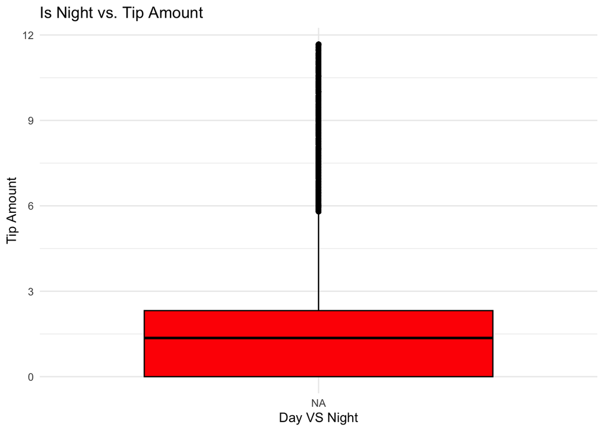

```r
# Plot relationship between Is Night and Tip Amount
ggplot(sample_cleaned, aes(x = factor(is_night), y = tip_amount)) +
  geom_boxplot(fill = "red", color = "black") +
  theme_minimal() +
  labs(title = "Is Night vs. Tip Amount", x = "Day VS Night", y = "Tip Amount")
```

In the initial attempt to plot the relationship between whether a trip occurred at night and the tip amount, I encountered an issue where the plot displayed an “NA” category. This happened because the `pickup_hour` variable was not correctly processed, leading to incorrect assignment in the `is_night` flag.

## 4.11(b) Is Night vs. Tip Amount (Corrected Approach)

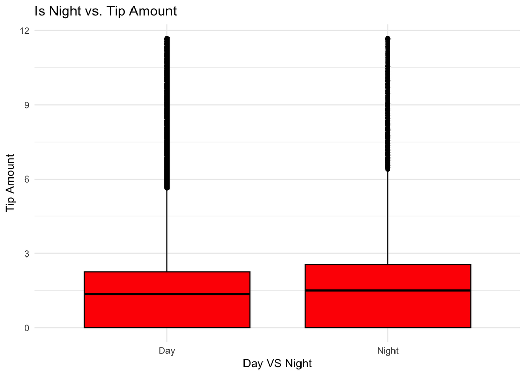

```r
sample_cleaned <- sample_cleaned %>%
  mutate(
    pickup_hour = as.numeric(pickup_hour),  # Convert to numeric if it's a factor
    is_night = ifelse(pickup_hour >= 22 | pickup_hour <= 5, "Night", "Day")  # Create is_night flag
  )
# Plot relationship between Is Night and Tip Amount
ggplot(sample_cleaned, aes(x = factor(is_night), y = tip_amount)) +
  geom_boxplot(fill = "red", color = "black") +
  theme_minimal() +
  labs(title = "Is Night vs. Tip Amount", x = "Day VS Night", y = "Tip Amount")
```

To fix the issue, I converted the `pickup_hour` variable to a numeric type and then correctly categorized trips as “Day” or “Night” based on the hour of pickup. This allowed the box plot to accurately reflect the distribution of tips for day and night trips.

### Observation

The corrected plot shows that there is no significant difference in the distribution of tip amounts between day and night trips. Both distributions are concentrated around lower tip amounts, with a similar spread across both categories.

## 4.12 Average Tip Amount by Pickup Hour and Time of Day, across the Week

```r
# Calculate average tip amount by hour, day, and night
avg_tips_by_hour <- sample_cleaned %>%
  group_by(day_of_week, pickup_hour, is_night) %>%
  summarise(avg_tip_amount = mean(tip_amount, na.rm = TRUE)) %>%
  ungroup()
```

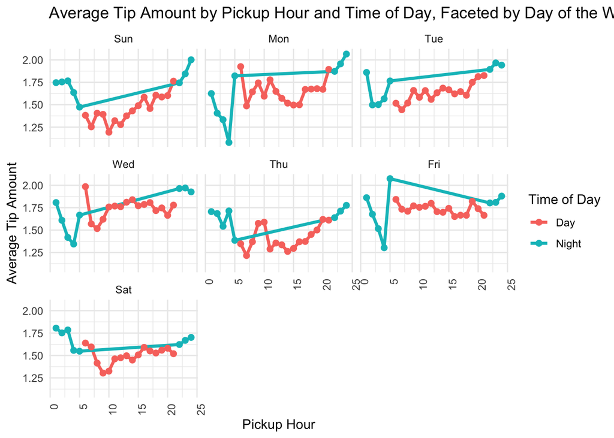

```r
# Create the line plot
ggplot(avg_tips_by_hour, aes(x = pickup_hour, y = avg_tip_amount, color = is_night, group = is_night)) +
  geom_line(size = 1.2) +
  geom_point(size = 2) +
  theme_minimal() +
  labs(title = "Average Tip Amount by Pickup Hour and Time of Day, Faceted by Day of the Week",
       x = "Pickup Hour", y = "Average Tip Amount", color = "Time of Day") +
  facet_wrap(~ day_of_week, ncol = 3) +
  theme(axis.text.x = element_text(angle = 90, hjust = 1))
```

To understand how tipping behavior varies across different times of the day and days of the week, I calculated the average tip amount grouped by pickup hour, day of the week, and whether the trip occurred during the day or night. This was then visualized in a faceted line plot, with each facet representing a different day of the week. The plot shows that average tip amounts tend to be higher during the night across most days, with noticeable dips during early morning hours. This suggests that both the time of day and the specific day of the week influence tipping behavior.

## 4.13 Density Plot of Tip Amount by Payment Type

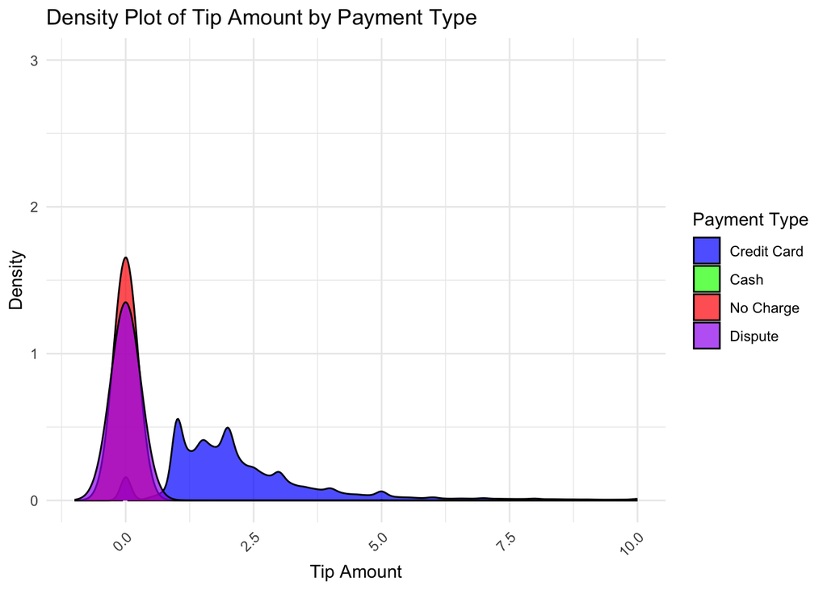

```r
ggplot(sample_cleaned, aes(x = tip_amount, fill = payment_type)) +
  geom_density(alpha = 0.7, color = "black") +  # Add color outline for better distinction
  theme_minimal() +
  labs(title = "Density Plot of Tip Amount by Payment Type",
       x = "Tip Amount", y = "Density", fill = "Payment Type") +
  xlim(-1, 10) +  # Limit the x-axis to the range 0-10 +
  ylim(0, 3) +
  scale_fill_manual(values = c("Credit Card" = "blue", "Cash" = "green",
                               "No Charge" = "red", "Dispute" = "purple")) +  # Assign distinct colors
  theme(axis.text.x = element_text(angle = 45, hjust = 1))
```

# 5. Model Construction

## 5.1 Subset Selection using regsubsets

```r
formula <- tip_amount ~ fare_amount + trip_distance + pickup_hour + dropoff_hour + day_of_week +
  passenger_count + payment_type + trip_duration
```

```r
# Perform subset selection
regfit <- regsubsets(formula, data = week2_cleaned, nvmax = 8)  # Adjust nvmax as needed

# Get the summary of the results
reg_summary <- summary(regfit)

# Find the best model based on Adjusted R²
best_model_index <- which.max(reg_summary$adjr2)
best_model <- coef(regfit, best_model_index)

print(best_model)
```

```
##           (Intercept)           fare_amount         trip_distance
##          0.9518462028          0.1044518904          0.0578954974
##          dropoff_hour         day_of_week.Q      payment_typeCash
##          0.0050128990         -0.1025781869         -2.2726763822
## payment_typeNo Charge   payment_typeDispute         trip_duration
##         -2.4655101496         -2.5587116631         -0.0002492332
```

## 5.2 Linear Regression and Backward Selection

```r
best_formula <- tip_amount ~ fare_amount + trip_distance + pickup_hour + dropoff_hour +
  day_of_week + payment_type + trip_duration

# Fit the linear regression model
lm_model <- lm(best_formula, data = week2_cleaned)
summary(lm_model)
```

```
##
## Call:
## lm(formula = best_formula, data = week2_cleaned)
##
## Residuals:
##     Min      1Q  Median      3Q     Max
## -7.5966 -0.4124  0.0263  0.5050  9.9370
##
## Coefficients:
##                         Estimate Std. Error   t value Pr(>|t|)
## (Intercept)            9.477e-01  2.448e-03   387.080  < 2e-16 ***
## fare_amount            1.047e-01  3.130e-04   334.612  < 2e-16 ***
## trip_distance          5.699e-02  9.290e-04    61.342  < 2e-16 ***
## pickup_hour            2.559e-03  3.564e-04     7.181 6.93e-13 ***
## dropoff_hour           2.661e-03  3.523e-04     7.553 4.24e-14 ***
## day_of_week.L         -2.791e-02  1.992e-03   -14.011  < 2e-16 ***
## day_of_week.Q         -9.892e-02  2.025e-03   -48.841  < 2e-16 ***
## day_of_week.C          2.243e-02  2.076e-03    10.802  < 2e-16 ***
## day_of_week^4         -1.304e-02  2.001e-03    -6.516 7.23e-11 ***
## day_of_week^5          1.150e-04  2.184e-03     0.053    0.958
## day_of_week^6         -9.342e-03  2.132e-03    -4.381 1.18e-05 ***
## payment_typeCash      -2.273e+00  1.665e-03 -1365.031  < 2e-16 ***
## payment_typeNo Charge -2.465e+00  1.266e-02  -194.670  < 2e-16 ***
## payment_typeDispute   -2.558e+00  2.256e-02  -113.393  < 2e-16 ***
## trip_duration         -2.479e-04  1.458e-05   -17.000  < 2e-16 ***
## ---
## Signif. codes:  0 '***' 0.001 '**' 0.01 '*' 0.05 '.' 0.1 ' ' 1
##
## Residual standard error: 1.122 on 2148146 degrees of freedom
## Multiple R-squared:  0.6432, Adjusted R-squared:  0.6432
## F-statistic: 2.767e+05 on 14 and 2148146 DF,  p-value: < 2.2e-16
```

```r
best_formula <- tip_amount ~ fare_amount + trip_distance + pickup_hour + dropoff_hour +
  day_of_week + payment_type + trip_duration

# Fit the model using the best formula
best_model <- lm(best_formula, data = week2_cleaned)
summary(best_model)
```

```
##
## Call:
## lm(formula = best_formula, data = week2_cleaned)
##
## Residuals:
##     Min      1Q  Median      3Q     Max
## -7.5966 -0.4124  0.0263  0.5050  9.9370
##
## Coefficients:
##                         Estimate Std. Error   t value Pr(>|t|)
## (Intercept)            9.477e-01  2.448e-03   387.080  < 2e-16 ***
## fare_amount            1.047e-01  3.130e-04   334.612  < 2e-16 ***
## trip_distance          5.699e-02  9.290e-04    61.342  < 2e-16 ***
## pickup_hour            2.559e-03  3.564e-04     7.181 6.93e-13 ***
## dropoff_hour           2.661e-03  3.523e-04     7.553 4.24e-14 ***
## day_of_week.L         -2.791e-02  1.992e-03   -14.011  < 2e-16 ***
## day_of_week.Q         -9.892e-02  2.025e-03   -48.841  < 2e-16 ***
## day_of_week.C          2.243e-02  2.076e-03    10.802  < 2e-16 ***
## day_of_week^4         -1.304e-02  2.001e-03    -6.516 7.23e-11 ***
## day_of_week^5          1.150e-04  2.184e-03     0.053    0.958
## day_of_week^6         -9.342e-03  2.132e-03    -4.381 1.18e-05 ***
## payment_typeCash      -2.273e+00  1.665e-03 -1365.031  < 2e-16 ***
## payment_typeNo Charge -2.465e+00  1.266e-02  -194.670  < 2e-16 ***
## payment_typeDispute   -2.558e+00  2.256e-02  -113.393  < 2e-16 ***
## trip_duration         -2.479e-04  1.458e-05   -17.000  < 2e-16 ***
## ---
## Signif. codes:  0 '***' 0.001 '**' 0.01 '*' 0.05 '.' 0.1 ' ' 1
##
## Residual standard error: 1.122 on 2148146 degrees of freedom
## Multiple R-squared:  0.6432, Adjusted R-squared:  0.6432
## F-statistic: 2.767e+05 on 14 and 2148146 DF,  p-value: < 2.2e-16
```

```r
# Perform backward selection starting from the full model
backward_model <- step(lm_model, direction = "backward")
```

```
## Start:  AIC=492689.8
## tip_amount ~ fare_amount + trip_distance + pickup_hour + dropoff_hour +
##     day_of_week + payment_type + trip_duration
##
##                 Df Sum of Sq     RSS     AIC
## <none>                       2701892  492690
## - pickup_hour    1        65 2701957  492739
## - dropoff_hour   1        72 2701964  492745
## - trip_duration  1       363 2702256  492977
## - day_of_week    6      3703 2705595  495620
## - trip_distance  1      4733 2706625  496447
## - fare_amount    1    140827 2842720  601833
## - payment_type   3   2376670 5078562 1848336
```

```r
summary(backward_model)
```

```
##
## Call:
## lm(formula = tip_amount ~ fare_amount + trip_distance + pickup_hour +
##     dropoff_hour + day_of_week + payment_type + trip_duration,
##     data = week2_cleaned)
##
## Residuals:
##     Min      1Q  Median      3Q     Max
## -7.5966 -0.4124  0.0263  0.5050  9.9370
##
## Coefficients:
##                         Estimate Std. Error   t value Pr(>|t|)
## (Intercept)            9.477e-01  2.448e-03   387.080  < 2e-16 ***
## fare_amount            1.047e-01  3.130e-04   334.612  < 2e-16 ***
## trip_distance          5.699e-02  9.290e-04    61.342  < 2e-16 ***
## pickup_hour            2.559e-03  3.564e-04     7.181 6.93e-13 ***
## dropoff_hour           2.661e-03  3.523e-04     7.553 4.24e-14 ***
## day_of_week.L         -2.791e-02  1.992e-03   -14.011  < 2e-16 ***
## day_of_week.Q         -9.892e-02  2.025e-03   -48.841  < 2e-16 ***
## day_of_week.C          2.243e-02  2.076e-03    10.802  < 2e-16 ***
## day_of_week^4         -1.304e-02  2.001e-03    -6.516 7.23e-11 ***
## day_of_week^5          1.150e-04  2.184e-03     0.053    0.958
## day_of_week^6         -9.342e-03  2.132e-03    -4.381 1.18e-05 ***
## payment_typeCash      -2.273e+00  1.665e-03 -1365.031  < 2e-16 ***
## payment_typeNo Charge -2.465e+00  1.266e-02  -194.670  < 2e-16 ***
## payment_typeDispute   -2.558e+00  2.256e-02  -113.393  < 2e-16 ***
## trip_duration         -2.479e-04  1.458e-05   -17.000  < 2e-16 ***
## ---
## Signif. codes:  0 '***' 0.001 '**' 0.01 '*' 0.05 '.' 0.1 ' ' 1
##
## Residual standard error: 1.122 on 2148146 degrees of freedom
## Multiple R-squared:  0.6432, Adjusted R-squared:  0.6432
## F-statistic: 2.767e+05 on 14 and 2148146 DF,  p-value: < 2.2e-16
```

# 5.3 Ridge Regression

Given the possibility of multicollinearity among predictors (where some predictors are highly correlated), a Ridge regression model was fitted. Ridge regression helps address multicollinearity by adding a penalty to the size of coefficients, thereby reducing the variance of the model and potentially improving prediction accuracy. This method is particularly useful when dealing with many predictors or when predictors are correlated.

```r
# Prepare data for Ridge regression
x_train <- model.matrix(best_formula, data = week2_cleaned)[, -1]
y_train <- week2_cleaned$tip_amount

# Fit Ridge regression model
ridge_model <- cv.glmnet(x_train, y_train, alpha = 0)  # alpha = 0 for Ridge

# Summary of the Ridge model
summary(ridge_model)
```

```
##            Length Class  Mode
## lambda     100    -none- numeric
## cvm        100    -none- numeric
## cvsd       100    -none- numeric
## cvup       100    -none- numeric
## cvlo       100    -none- numeric
## nzero      100    -none- numeric
## call         4    -none- call
## name         1    -none- character
## glmnet.fit  12    elnet  list
## lambda.min   1    -none- numeric
## lambda.1se   1    -none- numeric
## index        2    -none- numeric
```

```r
# Ensure pickup_hour exists in week4_data
week4_data <- week4_data %>%
  mutate(
    pickup_hour = hour(tpep_pickup_datetime),  # Assuming pickup_hour is derived from a datetime column
    dropoff_hour = hour(tpep_dropoff_datetime),  # Similarly for dropoff_hour
    day_of_week = wday(tpep_pickup_datetime, label = TRUE),
    trip_duration = as.numeric(difftime(tpep_dropoff_datetime, tpep_pickup_datetime, units = "mins")),
    trip_distance_bin = cut(trip_distance, breaks = c(0, 2, 5, 10, Inf), labels = c("Short", "Medium", "Long", "Very Long")),
    fare_bin = cut(fare_amount, breaks = c(0, 10, 20, 30, Inf), labels = c("Low", "Medium", "High", "Very High")),
    payment_type = factor(payment_type, levels = c(1, 2, 3, 4), labels = c("Credit Card", "Cash", "No Charge", "Dispute"))
  )
```

## 5.4 Model Evaluation

To compare the performance of the linear regression, backward selection, and Ridge regression models, several metrics were calculated, including AIC (Akaike Information Criterion), BIC (Bayesian Information Criterion), R², Adjusted R², and MSPE (Mean Squared Prediction Error). These metrics help assess the trade-off between model complexity and predictive accuracy.

```r
# Calculate AIC and BIC for Linear and Backward Selection models
lm_aic <- AIC(lm_model)
lm_bic <- BIC(lm_model)

backward_aic <- AIC(backward_model)
backward_bic <- BIC(backward_model)

# Predict on Week 4 data and calculate MSPE
week4_predictions_lm <- predict(lm_model, newdata = week4_data)
lm_mspe <- mean((week4_data$tip_amount - week4_predictions_lm)^2)

week4_predictions_backward <- predict(backward_model, newdata = week4_data)
backward_mspe <- mean((week4_data$tip_amount - week4_predictions_backward)^2)

# Ridge model predictions on Week 4 and MSPE
x_test <- model.matrix(best_formula, data = week4_data)[, -1]
week4_predictions_ridge <- predict(ridge_model, newx = x_test, s = "lambda.min")
ridge_mspe <- mean((week4_data$tip_amount - week4_predictions_ridge)^2)

# Calculate R² and Adjusted R² for all models
lm_r2 <- summary(lm_model)$r.squared
lm_adj_r2 <- summary(lm_model)$adj.r.squared

backward_r2 <- summary(backward_model)$r.squared
backward_adj_r2 <- summary(backward_model)$adj.r.squared

ridge_r2 <- 1 - sum((y_train - predict(ridge_model, x_train, s = "lambda.min"))^2) / sum((y_train - mean(y_train))^2)
ridge_adj_r2 <- 1 - (1 - ridge_r2) * (nrow(week2_cleaned) - 1) / (nrow(week2_cleaned) - ncol(x_train) - 1)

# Compile results into a data frame
model_comparison <- data.frame(
  Model = c("Linear", "Backward Selection", "Ridge"),
  AIC = c(lm_aic, backward_aic, NA),  # AIC not available for Ridge
  BIC = c(lm_bic, backward_bic, NA),  # BIC not available for Ridge
  R2 = c(lm_r2, backward_r2, ridge_r2),
  Adj_R2 = c(lm_adj_r2, backward_adj_r2, ridge_adj_r2),
  MSPE = c(lm_mspe, backward_mspe, ridge_mspe)
)

print(model_comparison)
```

```
##                Model     AIC     BIC        R2    Adj_R2     MSPE
## 1             Linear 6588909 6589110 0.6432481 0.6432457 552.3872
## 2 Backward Selection 6588909 6589110 0.6432481 0.6432457 552.3872
## 3              Ridge      NA      NA 0.6410133 0.6410109 313.1746
```

## 5.5 Cross-Validation and Final Model Selection

Given the potential for overfitting, especially with Ridge regression, cross-validation was employed to further validate the performance of the Ridge model. Cross-validation helps ensure that the model generalizes well to unseen data by splitting the dataset into training and validation sets multiple times.

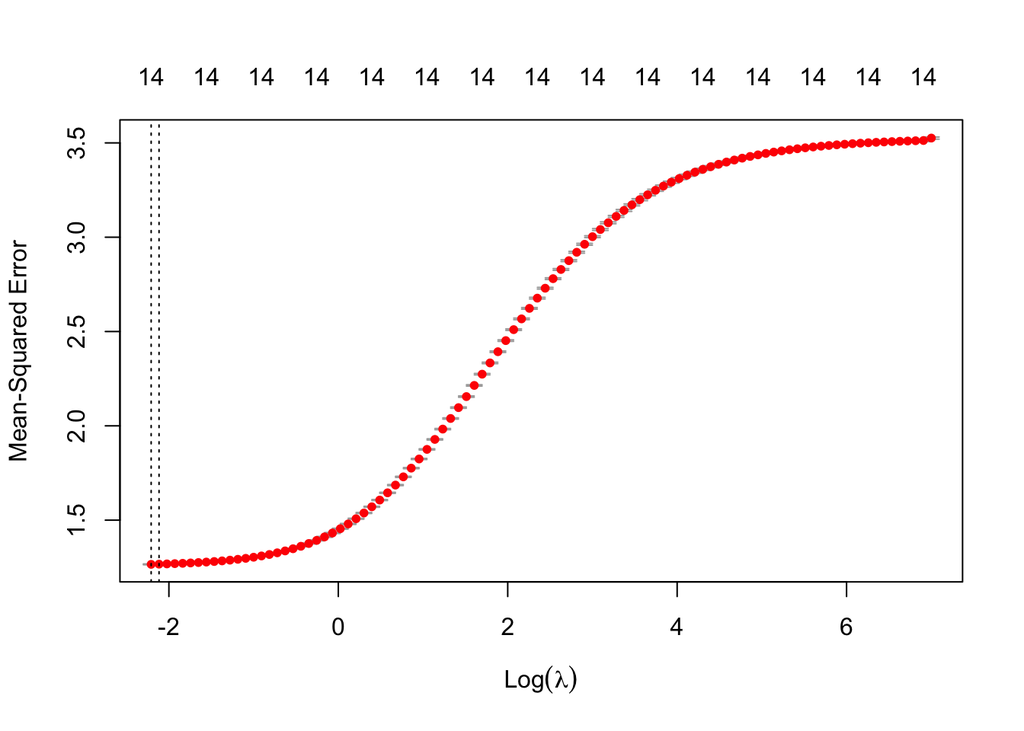

```r
# Perform cross-validation on the Ridge model
cv_ridge_model <- cv.glmnet(x_train, y_train, alpha = 0)
plot(cv_ridge_model)  # Plot the cross-validation curve
```

```r
# Identify the lambda with the minimum MSE
best_lambda <- cv_ridge_model$lambda.min
print(best_lambda)
```

```
## [1] 0.1097669
```

```r
# Fit the Ridge model using the best lambda
final_ridge_model <- glmnet(x_train, y_train, alpha = 0, lambda = best_lambda)

# Summary of the final Ridge model
summary(final_ridge_model)
```

```
##           Length Class     Mode
## a0         1     -none-    numeric
## beta      14     dgCMatrix S4
## df         1     -none-    numeric
## dim        2     -none-    numeric
## lambda     1     -none-    numeric
## dev.ratio  1     -none-    numeric
## nulldev    1     -none-    numeric
## npasses    1     -none-    numeric
## jerr       1     -none-    numeric
## offset     1     -none-    logical
## call       5     -none-    call
## nobs       1     -none-    numeric
```

The final model was selected based on the MSPE on the Week 4 data, which is a direct measure of prediction error on unseen data. The Ridge regression model was selected due to its robustness against multicollinearity and its better generalization ability, as indicated by cross-validation.

## 5.6 Final Model Prediction and Evaluation

```r
# Make final predictions on Week 4 data using the chosen model (Ridge)
final_predictions <- predict(final_ridge_model, newx = x_test)
final_mpse <- mean((week4_data$tip_amount - final_predictions)^2)

# Output the final MSPE
print(final_mpse)
```

```
## [1] 316.6829
```

# 6. Conclusion / Final Report

This lab aimed to construct a predictive model for estimating tip amounts for New York City taxi trips using data from February 2017. The process involved a series of critical steps, each contributing to the model’s development and performance.

## 6.1 Data Loading and Initial Exploration

We began by loading and exploring the datasets for Week 2 and Week 4 of February 2017. The initial exploration was crucial in understanding the structure of the data, identifying missing values, and recognizing irrelevant columns that could be dropped. This step set the foundation for subsequent data cleaning and transformation.

## *6.4 Feature Engineering and Data Transformation*

To enhance the predictive power of the model, several new features were engineered:

*Pickup and Dropoff Hour*: Extracting the hour from the pickup and dropoff timestamps allowed us to analyze time-based patterns in tipping behavior. This was particularly useful in identifying peaks in tipping during certain hours of the day.

*Day of the Week*: By extracting the day of the week, we could examine how tipping behavior varied across different days. For example, tips might be higher on weekends compared to weekdays.

*Trip Duration*: Calculating the duration of each trip provided insights into whether longer trips led to higher tips.

*Categorization of Trip Distance and Fare Amount*: Binning continuous variables like trip_distance and fare_amount into categories helped simplify the analysis and revealed distinct patterns within these ranges.

*Payment Type Factorization*: Converting payment_type into a factor allowed us to explore how different payment methods influenced tipping behavior.

These transformations were instrumental in structuring the data for exploratory data analysis (EDA) and modeling, making the dataset more intuitive and insightful.

## *6.5 Exploratory Data Analysis (EDA)*

EDA played a critical role in uncovering the relationships between tip_amount and other variables. Through various visualizations, we observed the following:

*Tip Amount Distribution*: Most tips were concentrated at lower values, with a significant drop-off as the tip amount increased. This pattern suggested that while larger tips occur, they are relatively rare.

*Trip Distance and Fare Amount Distribution*: The majority of trips were short, with fare amounts clustered around lower values. Understanding these distributions was key to setting realistic expectations for the model’s predictions.

*Time-Based Patterns*: Analyzing the pickup_hour and is_night variables showed that tips varied by the time of day and day of the week. However, no significant difference was found between day and night trips, suggesting that other factors may play a more critical role in determining tip amounts.

## *6.6 Model Construction and Evaluation*

Several models were constructed and evaluated to predict tip amounts:

*Subset Selection using regsubsets*: This method identified the best combination of predictors based on Adjusted R², helping to balance model complexity with predictive power.

*Linear Regression and Backward Selection*: The best predictors were used to fit a linear regression model, which was further refined using backward selection. Both approaches yielded similar results, indicating that almost all variables were significant in predicting tips.

*Ridge Regression*: Given the potential for multicollinearity among predictors, Ridge regression was employed. This technique added a penalty to the size of the coefficients, helping to reduce the model’s variance and improve its generalization ability.

*Model Comparison*: Metrics such as AIC, BIC, R², Adjusted R², and MSPE were calculated for each model. The Ridge regression model was selected as the final model due to its robustness against multicollinearity and better generalization to unseen data.

## *6.8 Understanding MSPE and Model Interpretation*

*Model Flaws:* Despite its strengths, the model may not capture all factors influencing tips, such as service quality or customer satisfaction. Additionally, it assumes a linear relationship between predictors and tips, which may not hold true for all variables.